# Practical Machine Learning Project

Aranda, Joey Ohmar I.

November 29, 2018

## Objective

The goal of the exercise is to predict the manner the people exercise given the data from wearable devices. Various prediction models thought to be appropriate in predicting the outcome “classe” were used. Comparisons were made based on their prediction performance.

## Libraries Used

library(caret)  
library(rattle)

## Getting started

```r
set.seed(1357)
```

```r
#Data Cleaning
trainingurl<-"https://d396qusza40orc.cloudfront.net/predmachlearn/pml-training.csv"
testingurl<-"https://d396qusza40orc.cloudfront.net/predmachlearn/pml-testing.csv"
traindata<-read.csv(url(trainingurl),na.strings = c("NA","","#DIV/0!"))
testdata<-read.csv(url(testingurl),na.strings = c("NA","","#DIV/0!"))
dim(traindata)
```

```
## [1] 19622   160
```

```r
dim(testdata)
```

```
## [1]  20 160
```

```r
traindatana<-which(colSums(is.na(traindata))>0.8*dim(traindata)[1])
cleantraindata<-traindata[,-traindatana]
cleantraindata<-cleantraindata[,-c(1:7)]
dim(cleantraindata)
```

```
## [1] 19622    53
```

```r
testdatana<-which(colSums(is.na(testdata))>0.8*dim(testdata)[1])
cleantestdata<-testdata[,-testdatana]
cleantestdata<-cleantestdata[,-c(1:7)]
dim(cleantestdata)
```

```
## [1] 20 53
```

The data provided consist of different values that can affect the performance of model building and prediction. “NA”,“”, and “#DIV/0!” were treated as NA values and the goal is to minimize the number of NAs in the dataset. For the purposes of this exercise, features that contain NAs greater than 80% of the number of rows of train/test data were filtered out. The first seven variables were also filtered out as these are the identifiers of the people that took the test and timestamps - information that do not tell anything about the activities performed.

```r
#Data Partition
inTrain<- createDataPartition(cleantraindata$classe, p = 3/4)[[1]]
cleantrainpart<- cleantraindata[inTrain,]
cleantestpart<-cleantraindata[-inTrain,]
```

The cleaned training data was partitioned to create another set of training and testing data. This is significant in model fitting so as not to saturate the model with the same values all throughtout the process. This will also help in calibrating the model for more accurate prediction of isolated data.

## Model Building

In model building, three variants of tree classifier methods were used: 1.) rpart which is the most basic decision tree method among the three 2.) rf (random forest) which involves bootstrapping and decision trees for prediction purposes and 3.) gbm (gradient boosting) uses regression trees for prediction.  
Cross-validation was also done to aid in detecting relevant features. 5-fold cross validation was used as this is seen sufficient for training. Smaller number of folds will also help minimize runtime.

### Tree Classifier

```r
start_time<-Sys.time()
modeltree<-train(classe ~.,data=cleantrainpart,method="rpart",trControl=trainControl(method="cv",number=5))
modtreepred<-predict(modeltree,cleantestpart)
confmattree<-confusionMatrix(modtreepred,cleantestpart$classe)
end_time<-Sys.time()
```

```r
end_time-start_time #rpart run time
```

```
## Time difference of 5.53124 secs
```

[figure not shown]

```r
fancyRpartPlot(modeltree$finalModel)
```

```r
print(modeltree)
```

```
## CART
##
## 14718 samples
##    52 predictor
##     5 classes: 'A', 'B', 'C', 'D', 'E'
##
## No pre-processing
## Resampling: Cross-Validated (5 fold)
## Summary of sample sizes: 11776, 11774, 11773, 11775, 11774
## Resampling results across tuning parameters:
##
##   cp          Accuracy   Kappa
##   0.02691541  0.5479015  0.41314465
##   0.04272287  0.5015658  0.35333716
##   0.11373778  0.3316444  0.07199705
##
## Accuracy was used to select the optimal model using the largest value.
## The final value used for the model was cp = 0.02691541.
```

```r
confmattree$table
```

```
##           Reference
## Prediction   A   B   C   D   E
##          A 886 169  24  47  13
##          B 138 554  38 128 226
##          C 270 183 666 430 196
##          D  98  43 127 199  44
##          E   3   0   0   0 422
```

```r
confmattree$overall[1]
```

```
##  Accuracy
## 0.5560767
```

Classic decision tree methods start with all variables in one group then find the variable that best separates the outcome. The process ends when the groups are too small or “pure”. The hierarchical nature of methods like rpart aids in interpretability. The drawback is that it does not perform particularly well considering the overall accuracy displayed above. With this, we can try other methods and see their performances.

### Random Forest

```r
start_time<-Sys.time()
modelrf<-train(classe ~ .,data=cleantrainpart,method="rf",trControl=trainControl(method="cv",number=5))
modrfpred<-predict(modelrf,cleantestpart)
confmatrf<-confusionMatrix(modrfpred,cleantestpart$classe)
end_time<-Sys.time()
```

```r
end_time-start_time #rf run time
```

```
## Time difference of 11.52487 mins
```

```r
print(modelrf)
```

```
## Random Forest
##
## 14718 samples
##    52 predictor
##     5 classes: 'A', 'B', 'C', 'D', 'E'
##
## No pre-processing
## Resampling: Cross-Validated (5 fold)
## Summary of sample sizes: 11775, 11774, 11774, 11774, 11775
## Resampling results across tuning parameters:
##
##   mtry  Accuracy   Kappa
##    2    0.9923224  0.9902871
##   27    0.9917789  0.9896001
##   52    0.9854603  0.9816061
##
## Accuracy was used to select the optimal model using the largest value.
## The final value used for the model was mtry = 2.
```

```r
confmatrf$table
```

```
##           Reference
## Prediction    A    B    C    D    E
##          A 1395    4    0    0    0
##          B    0  944    5    0    0
##          C    0    1  847   12    0
##          D    0    0    3  792    0
##          E    0    0    0    0  901
```

```r
confmatrf$overall[1]
```

```
##  Accuracy
## 0.9949021
```

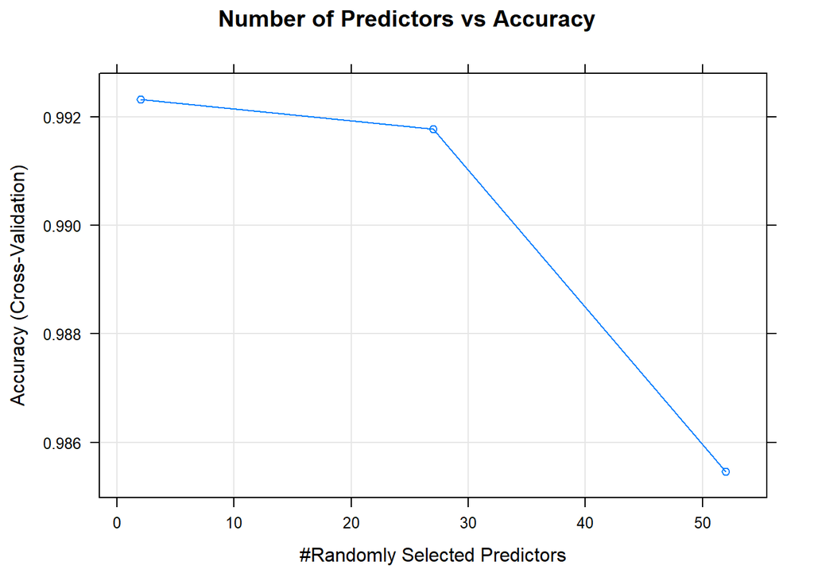

```r
plot(modelrf, main="Number of Predictors vs Accuracy")
```

```r
varImp(modelrf)
```

```
## rf variable importance
##
##   only 20 most important variables shown (out of 52)
##
##                      Overall
## roll_belt             100.00
## yaw_belt               81.20
## magnet_dumbbell_z      70.25
## magnet_dumbbell_y      62.00
## pitch_belt             61.45
## pitch_forearm          61.23
## magnet_dumbbell_x      51.00
## roll_forearm           50.89
## accel_belt_z           43.35
## accel_dumbbell_y       43.17
## magnet_belt_z          42.48
## roll_dumbbell          41.19
## magnet_belt_y          37.44
## accel_dumbbell_z       35.51
## roll_arm               33.80
## accel_forearm_x        33.02
## gyros_belt_z           29.95
## yaw_dumbbell           28.87
## total_accel_dumbbell   28.78
## accel_dumbbell_x       28.64
```

Random forest is an ensemble learning method that can be used for classification and regression problems. It can be thought of as a more complicated version of typical decision tree algorithms because it performs bootstrapping for training and testing before the creation of decision trees for prediction. Compared with rpart, rf method is seen as a much better algorithm given the accuracy. A plot was also given to show the relationship between the predictors and accuracy. This plot is useful in understanding the concept of bias-variance tradeoff. It doesn’t hold that the more predictors used, the better. Various predictors are correlated with one another, rendering them redundant in certain cases.

### Gradient Boosting

```r
start_time<-Sys.time()
modelgbm<-train(classe ~.,data=cleantrainpart,method="gbm",trControl=trainControl(method="cv",number=5))
modgbmpred<-predict(modelgbm,cleantestpart)
confmatgbm<-confusionMatrix(modgbmpred,cleantestpart$classe)
end_time<-Sys.time()
```

```r
end_time-start_time #gbm run time
```

```
## Time difference of 4.7878 mins
```

```r
print(modelgbm)
```

```
## Stochastic Gradient Boosting
##
## 14718 samples
##    52 predictor
##     5 classes: 'A', 'B', 'C', 'D', 'E'
##
## No pre-processing
## Resampling: Cross-Validated (5 fold)
## Summary of sample sizes: 11773, 11774, 11774, 11776, 11775
## Resampling results across tuning parameters:
##
##   interaction.depth  n.trees  Accuracy   Kappa
##   1                   50      0.7491493  0.6818563
##   1                  100      0.8188607  0.7706749
##   1                  150      0.8521522  0.8129141
##   2                   50      0.8526287  0.8132741
##   2                  100      0.9060333  0.8810867
##   2                  150      0.9327353  0.9148784
##   3                   50      0.8944153  0.8663289
##   3                  100      0.9408211  0.9251038
##   3                  150      0.9602529  0.9497135
##
## Tuning parameter 'shrinkage' was held constant at a value of 0.1
##
## Tuning parameter 'n.minobsinnode' was held constant at a value of 10
## Accuracy was used to select the optimal model using the largest value.
## The final values used for the model were n.trees = 150,
##  interaction.depth = 3, shrinkage = 0.1 and n.minobsinnode = 10.
```

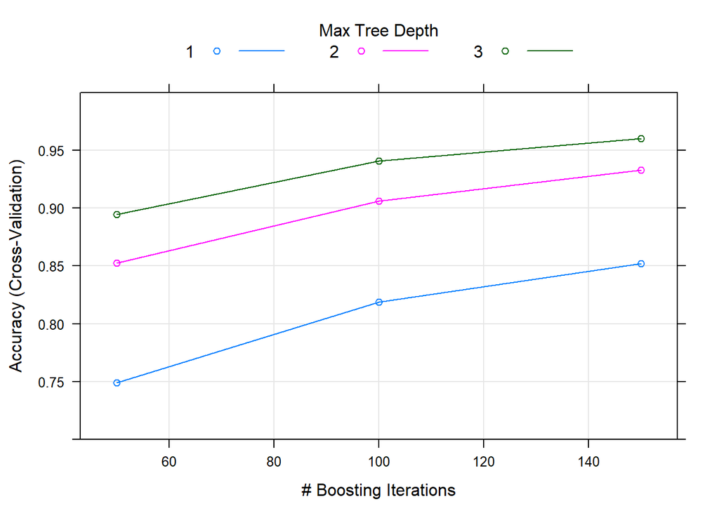

```r
plot(modelgbm,ylim=c(0.7,1.0))
```

```r
confmatgbm$table
```

```
##           Reference
## Prediction    A    B    C    D    E
##          A 1370   22    0    0    1
##          B   19  900   26    2   10
##          C    3   25  812   23    6
##          D    3    2   16  766    5
##          E    0    0    1   13  879
```

```r
confmatgbm$overall[1]
```

```
## Accuracy
## 0.963907
```

```r
bestmodrf<-predict(modelrf,newdata = cleantestdata)
bestmodrf
```

```
##  [1] B A B A A E D B A A B C B A E E A B B B
## Levels: A B C D E
```

## Conclusion

Practical machine learning methods vary in uses depending on what to predict. There is no one method that can be used to solve all types of problems. Utilization of methods depend on one’s need. One may be more inclined to use simpler methods for their interpretability while some may prefer complex or “blackbox” methods because they feel these are more robust. The performance of the methods used in this exercise were shown through their accuracy in prediction and process run time.